# UI/UX Design Tools

27 Februari 2024

## Do’a Belajar

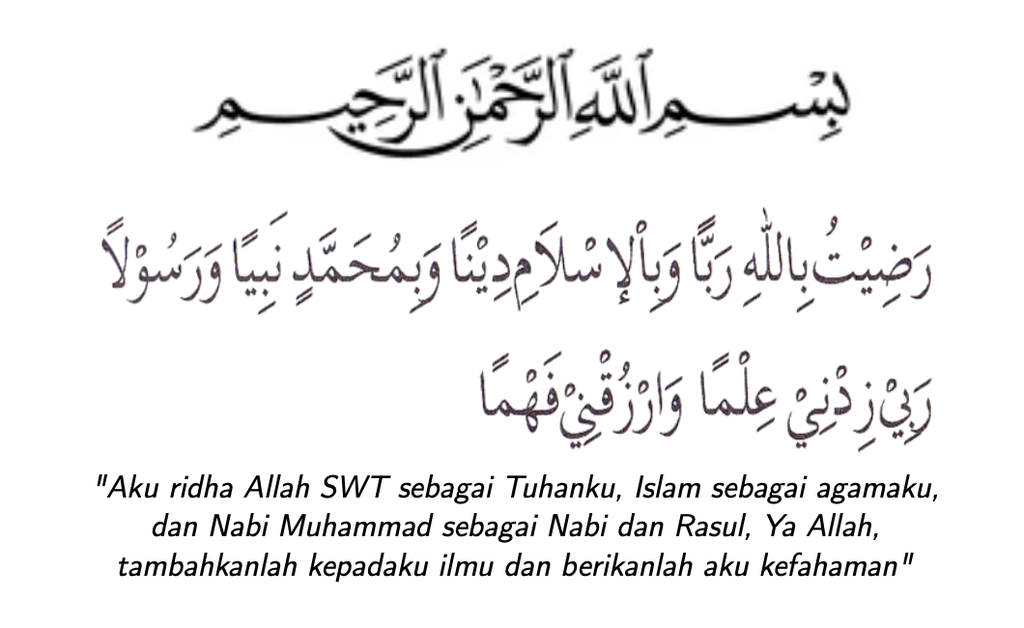

## Outline

- Macam-macam UI/UX Tools
- Notion
- Miro
- Spreadsheet
- Figma

## Macam-macam UI/UX Tools

## UI/UX Design Tools

[figure not shown]

## UI/UX Design Tools

[figure not shown]

## Notion

Notion adalah aplikasi yang membantu **meningkatkan produktivitas** dengan berbagai fitur.

**Fungsi:**

- Membuat catatan dokumentasi proyek
- Membuat database informasi
- Menjadi project management system (PMS)

[figure not shown]

## Fungsi Notion

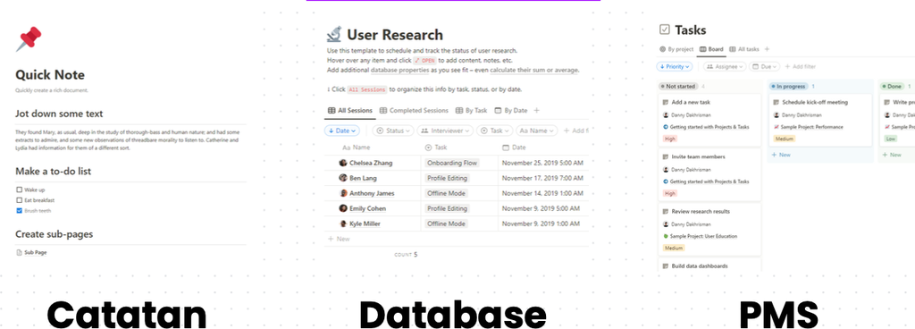

## Kelebihan Notion

- Gratis dan ada di berbagai platform
- Mengatur informasi dengan mudah dan cepat
- Multifungsi, mulai dari catatan database dan PMS

## Miro

Miro adalah **platform kolaborasi digital** yang memungkinkan tim untuk bekerja sama secara real time di papan tulis virtual.

**Fungsi:**

- Pemetaan masalah
- Brainstorming, dan
- Wireframe

[figure not shown]

## Fungsi Miro

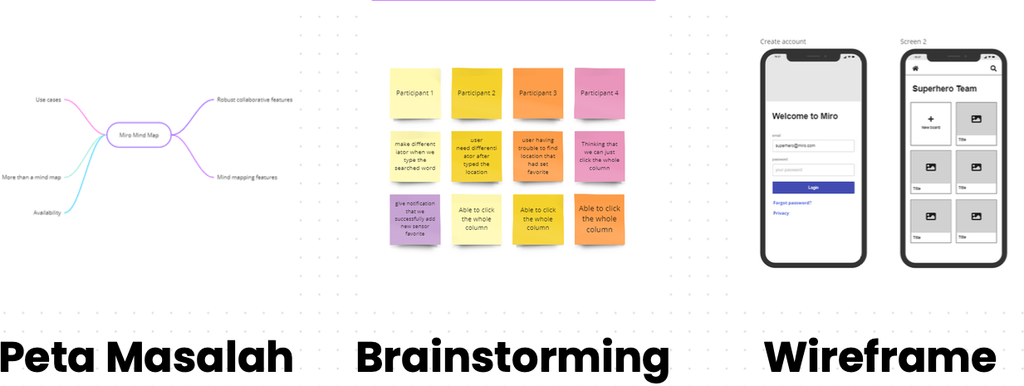

## Kelebihan Miro

- Gratis dan ada di berbagai platform
- Menjadi papan tulis virtual online
- Memiliki template untuk berbagai kebutuhan meeting

## Spreadsheet

Spreadsheet adalah aplikasi yang memungkinkan pengguna untuk **menyimpan data** yang berupa angka, teks, atau kombinasi keduanya dalam bentuk tabel.

**Fungsi:**

- Mencatat hasil diskusi
- Perhitungan
- Manipulasi data

[figure not shown]

## Fungsi Spreadsheet

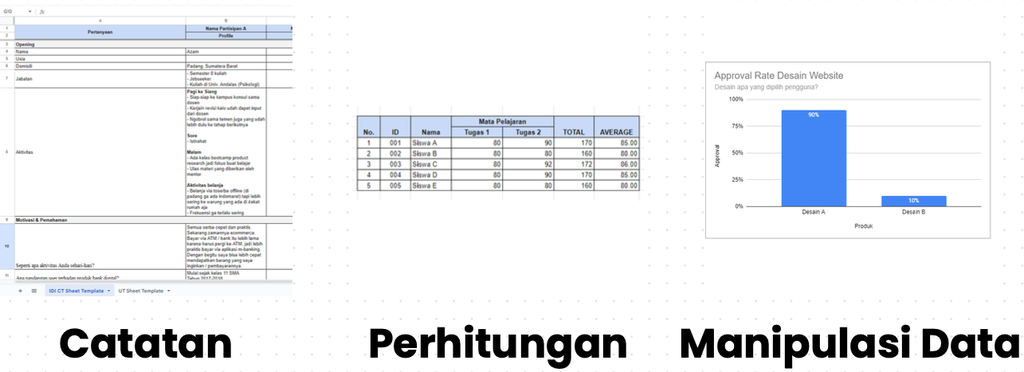

## Kelebihan Spreadsheet

- Gratis dan ada di berbagai platform
- Mengerjakan secara berkolaborasi
- Memproses informasi berupa data

## Figma

Figma adalah aplikasi design vector berbasis web yang dikhususkan untuk **mendesain tampilan antarmuka.**

**Fungsi:**

- Membuat wireframe
- Membuat user interface
- Melakukan prototyping

[figure not shown]

## Fungsi Figma

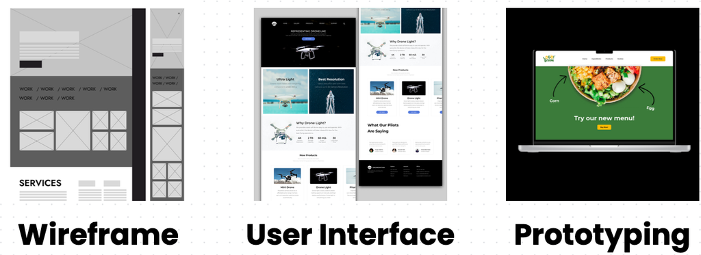

## Apa itu Figma?

[figure not shown]

Figma adalah aplikasi design vector **berbasis web** yang dikhususkan untuk mendesain **tampilan antarmuka**

## Produk Figma

[figure not shown]

## Figma Design

Figma merupakan salah satu aplikasi berbasis web di mana para contributor dapat mengubah ide-ide kreatif mereka menjadi sebuah **design yang responsif** dan **interaktif.**

Design ini dapat berupa design web, aplikasi, poster, dan lainnya.

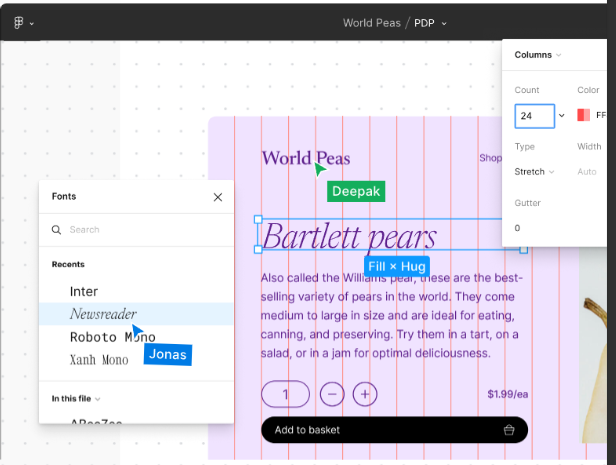

## Figma Community

[figure not shown]

Wadah untuk **mempublikasikan** file, plugin, dan widget bagi para penggunanya

## FigJam

FigJam adalah **whiteboarding online** yang membantu designer mendapatkan ide dan berkolaborasi dengan tim.

Seperti versi ringan Figma, **lebih mudah dipelajari** dan menyenangkan. Dengan fitur-fitur seperti catatan stiker, stamp, timer, notes dan alat gambar lainnya, tim dapat berbagi ide.

[figure not shown]

## Kelebihan dan Kekurangan Figma

Kelebihan:

- Kolaborasi dalam waktu bersamaan
- Share file dengan mudah
- Desain prototype dengan cepat dan mudah
- Berbasis awan (cloud)
- Mirror prototype

Kekurangan:

- Jaringan Internet
- Maintenance

## Mengapa Figma

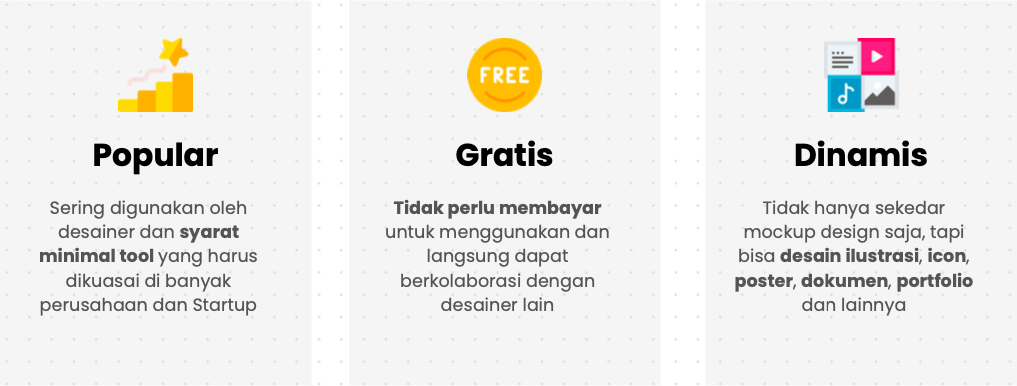

## Penutup

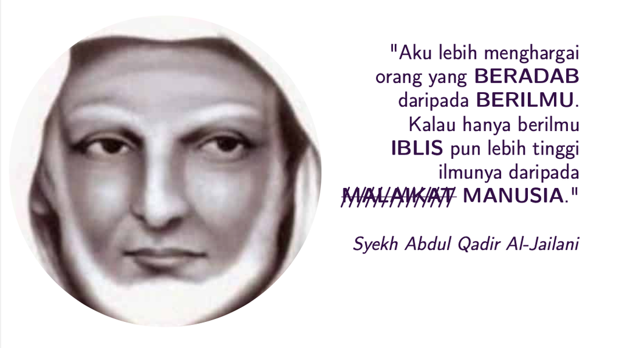